# DƏRS 6: Differensial Qiymətləndirmə və İnklüziv Yanaşmalar

Fərqli ehtiyacları olan tələbələr üçün adaptiv qiymətləndirmə

Azərbaycan Respublikası Təhsil Nazirliyi - Peşəkar İnkişaf Mərkəzi

2025-08-01

# 1 Dərsin Öyrənmə Məqsədləri

Bu dərsin sonunda siz aşağıdakıları bacara biləcəksiniz:

- **Differensial qiymətləndirmə prinsiplərini öyrənmək**
- **Müxtəlif öyrənmə ehtiyaclarını tanımaq və təsnif etmək**
- **İnklüziv qiymətləndirmə strategiyalarını tətbiq etmək**
- **Universal dizayn prinsiplərini mənimsəmək və istifadə etmək**
- **Xüsusi ehtiyacları olan tələbələr üçün adaptasiya strategiyaları hazırlamaq**
- **Ədalətli və əlçatan qiymətləndirmə mühiti yaratmaq**

# 2 Differensial Qiymətləndirmənin Əsasları

Differensial qiymətləndirmə tələbələrin fərdi ehtiyacları, bacarıqları və öyrənmə üslublarına uyğun olaraq qiymətləndirmə prosesini uyğunlaşdırma yanaşımıdır.

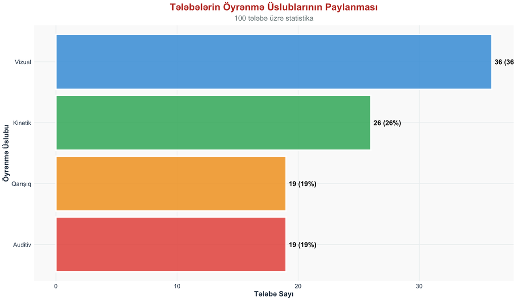

```r
# Fərdi fərqliliklərin növləri və paylanması
set.seed(2024)

student_profiles <- tibble(
  Student_ID = 1:100,
  Öyrənmə_Üslubu = sample(c("Vizual", "Auditiv", "Kinetik", "Qarışıq"), 100,
                          replace = TRUE, prob = c(0.35, 0.25, 0.20, 0.20)),
  Öyrənmə_Sürəti = sample(c("Tez", "Orta", "Yavaş"), 100,
                         replace = TRUE, prob = c(0.20, 0.60, 0.20)),
  Xüsusi_Ehtiyac = sample(c("Yoxdur", "Disleksiya", "ADHD", "Fiziki Məhdudiyyət", "Digər"), 100,
                         replace = TRUE, prob = c(0.75, 0.10, 0.08, 0.04, 0.03)),
  Dil_Fonu = sample(c("Ana dili", "İkinci dil", "Çoxdilli"), 100,
                   replace = TRUE, prob = c(0.70, 0.20, 0.10)),
  Performans_Səviyyəsi = rnorm(100, 75, 12)
) %>%
  mutate(
    Performans_Səviyyəsi = pmax(pmin(Performans_Səviyyəsi, 100), 40),
    Adaptasiya_Ehtiyacı = case_when(
      Xüsusi_Ehtiyac != "Yoxdur" ~ "Yüksək",
      Dil_Fonu != "Ana dili" ~ "Orta",
      Öyrənmə_Sürəti == "Yavaş" ~ "Orta",
      TRUE ~ "Aşağı"
    )
  )

# Öyrənmə üslublarının paylanması
learning_styles_dist <- student_profiles %>%
  count(Öyrənmə_Üslubu) %>%
  mutate(Percentage = round(n / sum(n) * 100, 1))

style_plot <- learning_styles_dist %>%
  ggplot(aes(x = reorder(Öyrənmə_Üslubu, n), y = n, fill = Öyrənmə_Üslubu)) +
  geom_col(alpha = 0.8, color = "white", size = 1) +
  geom_text(aes(label = paste0(n, " (", Percentage, "%)")),
            hjust = -0.1, fontface = "bold", size = 4) +
  scale_fill_manual(values = c("Vizual" = "#3498db", "Auditiv" = "#e74c3c",
                              "Kinetik" = "#27ae60", "Qarışıq" = "#f39c12")) +
  coord_flip() +
  labs(
    title = "Tələbələrin Öyrənmə Üslublarının Paylanması",
    subtitle = "100 tələbə üzrə statistika",
    x = "Öyrənmə Üslubu",
    y = "Tələbə Sayı",
    fill = "Üslub"
  ) +
  theme_differential() +
  theme(legend.position = "none")

print(style_plot)
```

```r
# Adaptasiya ehtiyacının təhlili
adaptation_need <- student_profiles %>%
  count(Adaptasiya_Ehtiyacı) %>%
  mutate(Percentage = round(n / sum(n) * 100, 1))

kable(adaptation_need,
      caption = "Tələbələrin Adaptasiya Ehtiyacı Paylanması",
      col.names = c("Adaptasiya Ehtiyacı", "Tələbə Sayı", "Faiz")) %>%
  kable_styling(bootstrap_options = c("striped", "hover", "condensed", "responsive")) %>%
  column_spec(1, bold = TRUE, color = "white", background = "#3498db") %>%
  column_spec(2:3, bold = TRUE)
```

Tələbələrin Adaptasiya Ehtiyacı Paylanması

| Adaptasiya Ehtiyacı | Tələbə Sayı | Faiz |
| --- | --- | --- |
| Aşağı | 37 | 37 |
| Orta | 37 | 37 |
| Yüksək | 26 | 26 |

```r
cat("📊 FƏRDI FƏRQLİLİKLƏR TƏHLİLİ:\n")
```

```
#> 📊 FƏRDI FƏRQLİLİKLƏR TƏHLİLİ:
```

```r
cat("==============================\n")
cat("👥 Ümumi tələbə sayı:", nrow(student_profiles), "\n")
```

```
#> 👥 Ümumi tələbə sayı: 100
```

```r
cat("🎯 Ən çox yayılmış öyrənmə üslubu:", learning_styles_dist$Öyrənmə_Üslubu[which.max(learning_styles_dist$n)],
    "(", max(learning_styles_dist$Percentage), "%)\n")
```

```
#> 🎯 Ən çox yayılmış öyrənmə üslubu: Vizual ( 36 %)
```

```r
cat("⚠️ Yüksək adaptasiya ehtiyacı:", sum(student_profiles$Adaptasiya_Ehtiyacı == "Yüksək"), "tələbə\n")
```

```
#> ⚠️ Yüksək adaptasiya ehtiyacı: 26 tələbə
```

```r
cat("🌍 Ana dili olmayan tələbələr:", sum(student_profiles$Dil_Fonu != "Ana dili"), "tələbə\n")
```

```
#> 🌍 Ana dili olmayan tələbələr: 38 tələbə
```

## 2.1 Fərdi Fərqliliklərin Növləri

**Öyrənmə Üslubları:**

- **Vizual öyrənicilər:** Diaqram, xəritə, rəng kodlaması, vizual təşkilatçılar
- **Auditiv öyrənicilər:** Şifahi təqdimat, müzakirə, səsli mətn oxuma
- **Kinetik öyrənicilər:** Praktik fəaliyyət, hərəkət, manipulativ materiallar
- **Qarışıq üslub:** Müxtəlif yanaşımları birləşdirən tələbələr

**Öyrənmə Sürəti:**

- **Tez öyrənənlər:** Əlavə tapşırıqlar, dərinləşdirilmiş məzmun
- **Orta templə öyrənənlər:** Standart yanaşma və material tempi
- **Yavaş öyrənənlər:** Əlavə vaxt, sadələşdirilmiş tapşırıqlar, təkrar

# 3 Adaptasiya Strategiyaları

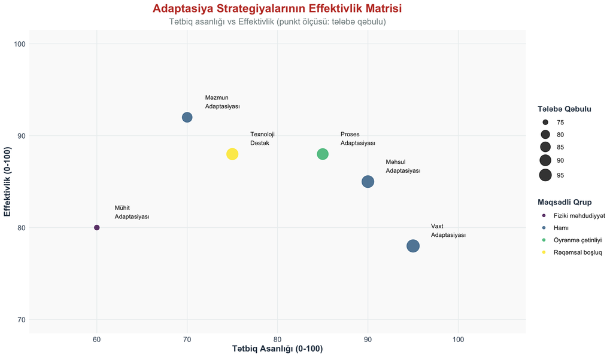

```r
# Adaptasiya strategiyalarının effektivlik təhlili
adaptation_strategies <- tibble(
  Strategiya = c("Məzmun Adaptasiyası", "Proses Adaptasiyası", "Məhsul Adaptasiyası",
                "Mühit Adaptasiyası", "Vaxt Adaptasiyası", "Texnoloji Dəstək"),
  Tətbiq_Asanlığı = c(70, 85, 90, 60, 95, 75),
  Effektivlik = c(92, 88, 85, 80, 78, 88),
  Tələbə_Qəbulu = c(85, 90, 95, 75, 98, 92),
  Resurs_Tələbi = c(80, 60, 70, 85, 40, 90),
  Məqsədli_Qrup = c("Hamı", "Öyrənmə çətinliyi", "Hamı", "Fiziki məhdudiyyət", "Hamı", "Rəqəmsal boşluq")
)

# Strategiya effektivlik matrisi
strategy_plot <- adaptation_strategies %>%
  ggplot(aes(x = Tətbiq_Asanlığı, y = Effektivlik)) +
  geom_point(aes(color = Məqsədli_Qrup, size = Tələbə_Qəbulu), alpha = 0.8) +
  geom_text(aes(label = str_wrap(Strategiya, 10)), hjust = 0, vjust = 0,
            nudge_x = 2, nudge_y = 1, size = 3) +
  scale_color_viridis_d(name = "Məqsədli Qrup") +
  scale_size_continuous(range = c(3, 8), name = "Tələbə Qəbulu") +
  scale_x_continuous(limits = c(55, 105)) +
  scale_y_continuous(limits = c(70, 100)) +
  labs(
    title = "Adaptasiya Strategiyalarının Effektivlik Matrisi",
    subtitle = "Tətbiq asanlığı vs Effektivlik (punkt ölçüsü: tələbə qəbulu)",
    x = "Tətbiq Asanlığı (0-100)",
    y = "Effektivlik (0-100)"
  ) +
  theme_differential()

print(strategy_plot)
```

```r
# Ən məqsədəuyğun strategiyalar
optimal_strategies <- adaptation_strategies %>%
  mutate(
    Optimal_Score = (Effektivlik * 0.35) + (Tətbiq_Asanlığı * 0.25) +
                   (Tələbə_Qəbulu * 0.25) + ((100 - Resurs_Tələbi) * 0.15)
  ) %>%
  arrange(desc(Optimal_Score)) %>%
  head(4)

kable(optimal_strategies %>% select(Strategiya, Effektivlik, Tətbiq_Asanlığı, Optimal_Score),
      caption = "Ən Məqsədəuyğun 4 Adaptasiya Strategiyası",
      col.names = c("Strategiya", "Effektivlik (%)", "Tətbiq Asanlığı (%)", "Optimal Bal")) %>%
  kable_styling(bootstrap_options = c("striped", "hover", "condensed", "responsive")) %>%
  column_spec(1, bold = TRUE, color = "white", background = "#3498db") %>%
  column_spec(2:4, bold = TRUE) %>%
  row_spec(1, background = "#d4edda")
```

Ən Məqsədəuyğun 4 Adaptasiya Strategiyası

| Strategiya | Effektivlik (%) | Tətbiq Asanlığı (%) | Optimal Bal |
| --- | --- | --- | --- |
| Vaxt Adaptasiyası | 78 | 95 | 84.55 |
| Proses Adaptasiyası | 88 | 85 | 80.55 |
| Məhsul Adaptasiyası | 85 | 90 | 80.50 |
| Texnoloji Dəstək | 88 | 75 | 74.05 |

```r
cat("\n🎯 STRATEGİYA TÖVSİYƏLƏRİ:\n")
```

```
#>
#> 🎯 STRATEGİYA TÖVSİYƏLƏRİ:
```

```r
cat("========================\n")
cat("🏆 Ən optimal strategiya:", optimal_strategies$Strategiya[1], "\n")
```

```
#> 🏆 Ən optimal strategiya: Vaxt Adaptasiyası
```

```r
cat("⚡ Ən asan tətbiq olunan:", adaptation_strategies$Strategiya[which.max(adaptation_strategies$Tətbiq_Asanlığı)], "\n")
```

```
#> ⚡ Ən asan tətbiq olunan: Vaxt Adaptasiyası
```

```r
cat("❤️ Ən çox qəbul edilən:", adaptation_strategies$Strategiya[which.max(adaptation_strategies$Tələbə_Qəbulu)], "\n")
```

```
#> ❤️ Ən çox qəbul edilən: Vaxt Adaptasiyası
```

```r
cat("🎯 Ən effektiv:", adaptation_strategies$Strategiya[which.max(adaptation_strategies$Effektivlik)], "\n")
```

```
#> 🎯 Ən effektiv: Məzmun Adaptasiyası
```

## 3.1 Məzmun Adaptasiyası

**Müxtəlif mürəkkəblik səviyyələri:** - Əsas, orta və inkişaf etmiş versiyalar - Qabaqcıl tələbələr üçün əlavə materiallar - Əsas konseptlərin sadələşdirilmiş izahları

**Çoxsaylı nümunə və izahat:** - Mücərrəd anlayışlar üçün konkret nümunələr - Real həyatdan analoqlar və metaforalar - Addım-addım təlimatlar və istiqamətlər

**Vizual dəstək materialları:** - İnfoqrafiklər və diaqramlar - Rəng kodlaması və vizual təşkilatçılar - Video və animasiya elementləri

## 3.2 Proses Adaptasiyası

**Fərdi və qrup işi balansı:** - Müstəqil iş imkanları - Kollaborativ layihələr - Mürşidlik və mentorluq sistemi

**Müxtəlif təqdimat formatları:** - Şifahi, yazılı və vizual təqdimatlar - Rəqəmsal və ənənəvi formatlar - İnteraktiv və passiv variantlar

**Mərhələli tapşırıq verilməsi:** - Böyük layihələrin kiçik hissələrə bölünməsi - Aralıq yoxlama nöqtələri - Çeviklik və uyğunlaşma imkanları

# 4 Xüsusi Ehtiyacları Olan Tələbələr üçün Adaptasiya

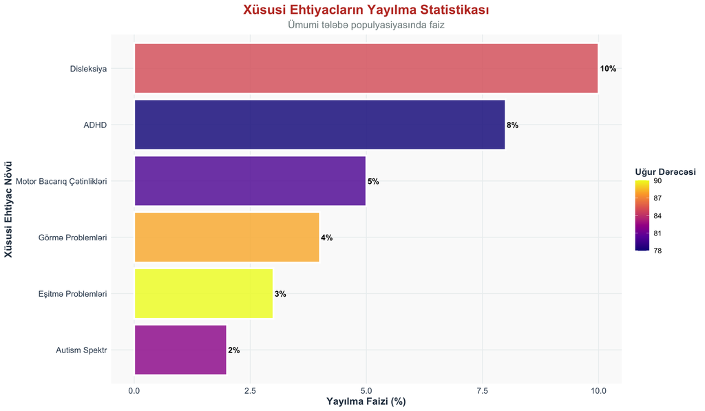

```r
# Xüsusi ehtiyaclar və adaptasiya strategiyaları
special_needs_data <- tibble(
  Ehtiyac_Növü = c("Disleksiya", "ADHD", "Autism Spektr", "Eşitmə Problemləri",
                   "Görmə Problemləri", "Motor Bacarıq Çətinlikləri"),
  Yayılma_Faizi = c(10, 8, 2, 3, 4, 5),
  Əsas_Adaptasiya = c("Audio alətlər", "Struktur və rutinlər", "Aydın təlimatlar",
                     "Vizual dəstək", "Audio təsvir", "Texnoloji köməkçilər"),
  Qiymətləndirmə_Dəyişikliyi = c("Şifahi", "Qısa seqmentlər", "Vizual rubrik",
                                "Yazılı format", "Şifahi təqdimat", "Rəqəmsal format"),
  Uğur_Dərəcəsi = c(85, 78, 82, 90, 88, 80)
)

# Xüsusi ehtiyacların paylanması
needs_plot <- special_needs_data %>%
  ggplot(aes(x = reorder(Ehtiyac_Növü, Yayılma_Faizi), y = Yayılma_Faizi,
             fill = Uğur_Dərəcəsi)) +
  geom_col(alpha = 0.8, color = "white", size = 1) +
  geom_text(aes(label = paste0(Yayılma_Faizi, "%")),
            hjust = -0.1, fontface = "bold", size = 3.5) +
  scale_fill_viridis_c(name = "Uğur Dərəcəsi", option = "plasma") +
  coord_flip() +
  labs(
    title = "Xüsusi Ehtiyacların Yayılma Statistikası",
    subtitle = "Ümumi tələbə populyasiyasında faiz",
    x = "Xüsusi Ehtiyac Növü",
    y = "Yayılma Faizi (%)"
  ) +
  theme_differential()

print(needs_plot)
```

```r
# Adaptasiya strategiyalarının effektivliyi
adaptation_effectiveness <- special_needs_data %>%
  select(Ehtiyac_Növü, Uğur_Dərəcəsi, Əsas_Adaptasiya) %>%
  arrange(desc(Uğur_Dərəcəsi))

kable(adaptation_effectiveness,
      caption = "Xüsusi Ehtiyaclar üçün Adaptasiya Strategiyalarının Effektivliyi",
      col.names = c("Ehtiyac Növü", "Uğur Dərəcəsi (%)", "Əsas Adaptasiya Strategiyası")) %>%
  kable_styling(bootstrap_options = c("striped", "hover", "condensed", "responsive")) %>%
  column_spec(1, bold = TRUE, color = "white", background = "#3498db") %>%
  column_spec(2, bold = TRUE, color = "#27ae60") %>%
  row_spec(1:2, background = "#d4edda")
```

Xüsusi Ehtiyaclar üçün Adaptasiya Strategiyalarının Effektivliyi

| Ehtiyac Növü | Uğur Dərəcəsi (%) | Əsas Adaptasiya Strategiyası |
| --- | --- | --- |
| Eşitmə Problemləri | 90 | Vizual dəstək |
| Görmə Problemləri | 88 | Audio təsvir |
| Disleksiya | 85 | Audio alətlər |
| Autism Spektr | 82 | Aydın təlimatlar |
| Motor Bacarıq Çətinlikləri | 80 | Texnoloji köməkçilər |
| ADHD | 78 | Struktur və rutinlər |

```r
cat("\n♿ XÜSUSİ EHTİYACLAR TƏHLİLİ:\n")
```

```
#>
#> ♿ XÜSUSİ EHTİYACLAR TƏHLİLİ:
```

```r
cat("============================\n")
cat("📊 Ümumi xüsusi ehtiyac nisbəti:", sum(special_needs_data$Yayılma_Faizi), "%\n")
```

```
#> 📊 Ümumi xüsusi ehtiyac nisbəti: 32 %
```

```r
cat("🎯 Ən yüksək uğur dərəcəsi:", special_needs_data$Ehtiyac_Növü[which.max(special_needs_data$Uğur_Dərəcəsi)],
    "(", max(special_needs_data$Uğur_Dərəcəsi), "%)\n")
```

```
#> 🎯 Ən yüksək uğur dərəcəsi: Eşitmə Problemləri ( 90 %)
```

```r
cat("📈 Orta uğur dərəcəsi:", round(mean(special_needs_data$Uğur_Dərəcəsi), 1), "%\n")
```

```
#> 📈 Orta uğur dərəcəsi: 83.8 %
```

## 4.1 Öyrənmə Çətinlikləri

**Disleksiya:** - Şifahi təqdimat imkanları təklif etmək - Daha böyük şrift və sətir aralığı istifadə etmək - Audio yazı alətlərindən yararlanmaq - Əlavə vaxt ayrılması və tələsik olmama

**ADHD (Diqqət Çatışmazlığı və Hiperaktivlik):** - Qısa, aydın və sadə təlimatlar vermək - Tez-tez fasilələr təşkil etmək - Strukturlaşdırılmış mühit təmin etmək - Vizual organizerlər və xatırlatıcılardan istifadə

**Autism Spektr Pozğunluqları:** - Aydın və dəqiq təlimatlar - Rutinlərdən çıxmamaqlıq - Vizual dəstək materialları - Sosial vəziyyətlərdə əlavə köməklik

## 4.2 Fiziki Məhdudiyyətlər

**Motor Bacarıq Problemləri:** - Klaviatura və ya səsli yazı sistemləri - Böyük düymələr və ergonomik alətlər - Fiziki dəstək və adaptiv texnologiya - Rəqəmsal təqdimat formatlarına üstünlük

**Görmə Çətinlikləri:** - Böyük şrift və yüksək kontrast - Audio təsvir və səsli mətnlər - Braille və ya taktil materiallar - Ekran oxuyucu texnologiyaları

**Eşitmə Çətinlikləri:** - Vizual dəstək materialları - Yazılı təlimatlar və mətnlər - İşarə dili tərcüməçisi dəsteyi - Vibrasiya və vizual siqnallar

# 5 Universal Dizayn Prinsipləri (UDL)

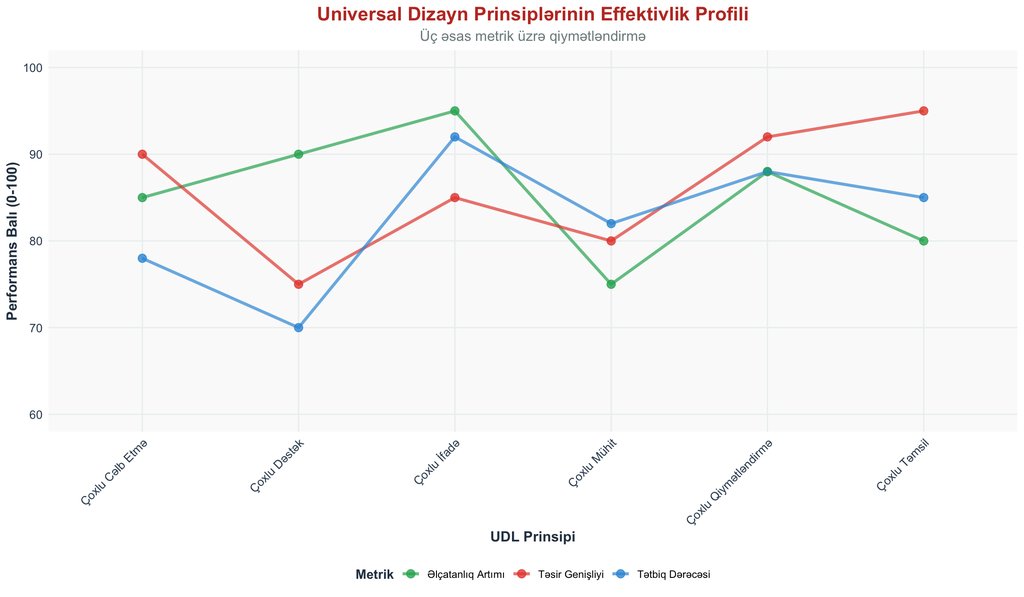

```r
# Universal Dizayn prinsiplərinin tətbiqi
udl_principles <- tibble(
  Prinsip = c("Çoxlu Təmsil", "Çoxlu Cəlb Etmə", "Çoxlu İfadə",
              "Çoxlu Dəstək", "Çoxlu Mühit", "Çoxlu Qiymətləndirmə"),
  Təsvir = c("Məlumatı müxtəlif formatlarda təqdim", "Fərqli motivasiya yolları",
            "Alternativ cavab və təqdimat üsulları", "Müxtəlif səviyyədə köməklik",
            "Fiziki və rəqəmsal mühit seçimləri", "Çoxsaylı qiymətləndirmə metodu"),
  Tətbiq_Dərəcəsi = c(85, 78, 92, 70, 82, 88),
  Təsir_Genişliyi = c(95, 90, 85, 75, 80, 92),
  Əlçatanlıq_Artımı = c(80, 85, 95, 90, 75, 88)
)

# UDL prinsiplərinin radar çartı
udl_long <- udl_principles %>%
  select(Prinsip, Tətbiq_Dərəcəsi, Təsir_Genişliyi, Əlçatanlıq_Artımı) %>%
  pivot_longer(cols = -Prinsip, names_to = "Metrik", values_to = "Bal") %>%
  mutate(
    Metrik = case_when(
      Metrik == "Tətbiq_Dərəcəsi" ~ "Tətbiq Dərəcəsi",
      Metrik == "Təsir_Genişliyi" ~ "Təsir Genişliyi",
      Metrik == "Əlçatanlıq_Artımı" ~ "Əlçatanlıq Artımı"
    )
  )

udl_plot <- udl_long %>%
  ggplot(aes(x = Prinsip, y = Bal, color = Metrik, group = Metrik)) +
  geom_point(size = 3, alpha = 0.8) +
  geom_line(size = 1.2, alpha = 0.7) +
  scale_color_manual(values = c("Tətbiq Dərəcəsi" = "#3498db",
                               "Təsir Genişliyi" = "#e74c3c",
                               "Əlçatanlıq Artımı" = "#27ae60")) +
  scale_y_continuous(limits = c(60, 100), breaks = seq(60, 100, 10)) +
  labs(
    title = "Universal Dizayn Prinsiplərinin Effektivlik Profili",
    subtitle = "Üç əsas metrik üzrə qiymətləndirmə",
    x = "UDL Prinsipi",
    y = "Performans Balı (0-100)",
    color = "Metrik"
  ) +
  theme_differential() +
  theme(
    axis.text.x = element_text(angle = 45, hjust = 1),
    legend.position = "bottom"
  )

print(udl_plot)
```

```r
# UDL tətbiq təlimatları
udl_implementation <- tibble(
  UDL_Komponenti = c("Çoxlu Təmsil Vasitələri", "Çoxlu Cəlb Etmə Yolları", "Çoxlu İfadə Yolları"),
  Təqdimat_Formatı = c("Mətn, Audio, Video, İnfoqrafik", "Seçim, Əməkdaşlıq, Rəqabət",
                      "Yazılı, Şifahi, Vizual, Praktik"),
  Texnoloji_Dəstək = c("Multimedia, VR/AR, İnteraktiv", "Oyunlaşdırma, Sosial şəbəkə",
                      "Rəqəmsal alətlər, Mobil tətbiqlər"),
  Tələbə_Seçimi = c("Format seçimi", "Maraq sahəsi", "Təqdimat üsulu"),
  Effektivlik_Balı = c(88, 85, 92)
)

kable(udl_implementation,
      caption = "Universal Dizayn Prinsiplərinin Tətbiq Təlimatları",
      col.names = c("UDL Komponenti", "Təqdimat Formatı", "Texnoloji Dəstək",
                   "Tələbə Seçimi", "Effektivlik")) %>%
  kable_styling(bootstrap_options = c("striped", "hover", "condensed", "responsive")) %>%
  column_spec(1, bold = TRUE, color = "white", background = "#3498db") %>%
  column_spec(5, bold = TRUE, color = "#27ae60")
```

Universal Dizayn Prinsiplərinin Tətbiq Təlimatları

| UDL Komponenti | Təqdimat Formatı | Texnoloji Dəstək | Tələbə Seçimi | Effektivlik |
| --- | --- | --- | --- | --- |
| Çoxlu Təmsil Vasitələri | Mətn, Audio, Video, İnfoqrafik | Multimedia, VR/AR, İnteraktiv | Format seçimi | 88 |
| Çoxlu Cəlb Etmə Yolları | Seçim, Əməkdaşlıq, Rəqabət | Oyunlaşdırma, Sosial şəbəkə | Maraq sahəsi | 85 |
| Çoxlu İfadə Yolları | Yazılı, Şifahi, Vizual, Praktik | Rəqəmsal alətlər, Mobil tətbiqlər | Təqdimat üsulu | 92 |

```r
cat("\n🌍 UNİVERSAL DİZAYN TƏHLİLİ:\n")
```

```
#>
#> 🌍 UNİVERSAL DİZAYN TƏHLİLİ:
```

```r
cat("============================\n")
cat("🎯 Ən effektiv UDL prinsipi:", udl_implementation$UDL_Komponenti[which.max(udl_implementation$Effektivlik_Balı)], "\n")
```

```
#> 🎯 Ən effektiv UDL prinsipi: Çoxlu İfadə Yolları
```

```r
cat("📊 Orta effektivlik:", round(mean(udl_implementation$Effektivlik_Balı), 1), "%\n")
```

```
#> 📊 Orta effektivlik: 88.3 %
```

```r
cat("🌟 Hərtərəfli təsir dərəcəsi:", round(mean(udl_principles$Təsir_Genişliyi), 1), "%\n")
```

```
#> 🌟 Hərtərəfli təsir dərəcəsi: 86.2 %
```

## 5.1 1. Çoxlu Təmsil Vasitələri

**Məlumatı müxtəlif formatlarda təqdim etmək:** - Mətn, audio, video və vizual materiallar - İnteraktiv simulyasiyalar və virtual reallıq - Çoxdilli dəstək və mədəni kontekst

**Bilgini aktivləşdirmə:** - Əvvəlki biliklərlə əlaqələndirmə - Analoq və metaforlardan istifadə - Kontekstual nümunələr təqdim etmə

## 5.2 2. Çoxlu Cəlb Etmə Yolları

**Müxtəlif motivasiya strategiyaları:** - Şəxsi maraq və seçim imkanları - Sosial əlaqələr və həmyaşıd dəsteyi - Mədəni relevantlıq və real həyat əlaqələri

**Özünütənzimləmə dəsteyi:** - Məqsəd qoyma və izləmə alətləri - Özünü qiymətləndirmə vasitələri - Stress idarəetməsi strategiyaları

## 5.3 3. Çoxlu İfadə Yolları

**Alternativ cavab və təqdimat üsulları:** - Yazılı, şifahi, vizual və praktik formatlar - Texnoloji alətlər və assistiv texnologiyalar - Kollaborativ və fərdi iş imkanları

**İcra funksiyalarına dəstək:** - Planlaşdırma və təşkilat alətləri - Zaman idarəetməsi köməkçiləri - Mərhələli tapşırıq strukturu

# 6 İnklüziv Qiymətləndirmə Rubrikləri

```r
# İnklüziv rubrik nümunəsi
inclusive_rubric <- tibble(
  Kriteriya = rep(c("Məzmun və İdeya", "Struktur və Təşkilat", "Dil və Üslub", "Yaradıcılıq"), each = 4),
  Səviyyə = rep(c("Əla (4)", "Yaxşı (3)", "Kifayət (2)", "İnkişaf (1)"), 4),
  Ənənəvi_Təsvir = c(
    # Məzmun
    "Orijinal, dərin fikirlərlə zəngin", "Yaxşı inkişaf etmiş ideyalar",
    "Ümumi ideyalar, az ətraflı", "Zəif inkişaf etmiş ideyalar",
    # Struktur
    "Mükəmməl təşkilat, aydın keçidlər", "Yaxşı strukturlaşdırılmış",
    "Əsas struktur mövcud", "Zəif təşkilat, qarışıq",
    # Dil
    "Zəngin lüğət, effektiv ifadə", "Müvafiq dil istifadəsi",
    "Sadə amma düzgün dil", "Məhdud lüğət, zəif ifadə",
    # Yaradıcılıq
    "Çox orijinal və innovativ", "Bəzi yaradıcı elementlər",
    "Məhdud yaradıcılıq", "Yaradıcılıq yoxdur"
  ),
  İnklüziv_Təsvir = c(
    # Məzmun - İnklüziv
    "Öz təcrübəsinə əsasən dərin fikirlərlə", "Şəxsi perspektivdən yaxşı inkişaf",
    "Əsas fikirləri öz üslubunda ifadə", "Öz yolunda ideya inkişafına cəhd",
    # Struktur - İnklüziv
    "Özünə uyğun aydın təşkilat", "Şəxsi üslubda strukturlaşdırma",
    "Öz yolunda əsas struktur", "Fərdi tempində təşkilat cəhdi",
    # Dil - İnklüziv
    "Öz dil imkanlarından effektiv istifadə", "Şəxsi ifadə üslubunda müvafiq",
    "Fərdi dil bacarıqlarına uyğun", "Öz səviyyəsində səmimi ifadə",
    # Yaradıcılıq - İnklüziv
    "Şəxsi yaradıcılıq nümayişi", "Fərdi yanaşımda yaradıcı elementlər",
    "Öz imkanları çərçivəsində yaradıcılıq", "Yaradıcılığa cəhd və təşəbbüs"
  )
)

# Rubrik fərqinin görüntülənməsi
rubric_comparison <- inclusive_rubric %>%
  filter(Səviyyə %in% c("Əla (4)", "İnkişaf (1)")) %>%
  select(Kriteriya, Səviyyə, Ənənəvi_Təsvir, İnklüziv_Təsvir) %>%
  arrange(Kriteriya, desc(Səviyyə))

kable(rubric_comparison,
      caption = "Ənənəvi və İnklüziv Rubrik Yanaşımlarının Müqayisəsi",
      col.names = c("Kriteriya", "Səviyyə", "Ənənəvi Yanaşım", "İnklüziv Yanaşım")) %>%
  kable_styling(bootstrap_options = c("striped", "hover", "condensed", "responsive")) %>%
  column_spec(1, bold = TRUE, color = "white", background = "#3498db") %>%
  column_spec(2, bold = TRUE) %>%
  column_spec(3, background = "#fef5e7") %>%
  column_spec(4, background = "#d4edda") %>%
  row_spec(c(1,3,5,7), background = "#e8f5e8") %>%
  row_spec(c(2,4,6,8), background = "#fff3cd")
```

Ənənəvi və İnklüziv Rubrik Yanaşımlarının Müqayisəsi

| Kriteriya | Səviyyə | Ənənəvi Yanaşım | İnklüziv Yanaşım |
| --- | --- | --- | --- |
| Dil və Üslub | Əla (4) | Zəngin lüğət, effektiv ifadə | Öz dil imkanlarından effektiv istifadə |
| Dil və Üslub | İnkişaf (1) | Məhdud lüğət, zəif ifadə | Öz səviyyəsində səmimi ifadə |
| Məzmun və İdeya | Əla (4) | Orijinal, dərin fikirlərlə zəngin | Öz təcrübəsinə əsasən dərin fikirlərlə |
| Məzmun və İdeya | İnkişaf (1) | Zəif inkişaf etmiş ideyalar | Öz yolunda ideya inkişafına cəhd |
| Struktur və Təşkilat | Əla (4) | Mükəmməl təşkilat, aydın keçidlər | Özünə uyğun aydın təşkilat |
| Struktur və Təşkilat | İnkişaf (1) | Zəif təşkilat, qarışıq | Fərdi tempində təşkilat cəhdi |
| Yaradıcılıq | Əla (4) | Çox orijinal və innovativ | Şəxsi yaradıcılıq nümayişi |
| Yaradıcılıq | İnkişaf (1) | Yaradıcılıq yoxdur | Yaradıcılığa cəhd və təşəbbüs |

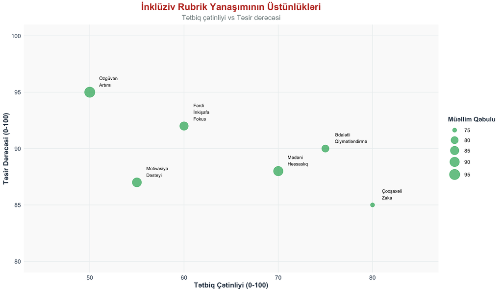

```r
# İnklüziv rubrik üstünlüklərinin təhlili
inclusive_benefits <- tibble(
  Üstünlük = c("Fərdi İnkişafa Fokus", "Mədəni Həssaslıq", "Özgüvən Artımı",
               "Ədalətli Qiymətləndirmə", "Motivasiya Dəsteyi", "Çoxşaxəli Zəka"),
  Təsir_Dərəcəsi = c(92, 88, 95, 90, 87, 85),
  Tətbiq_Çətinliyi = c(60, 70, 50, 75, 55, 80),
  Müəllim_Qəbulu = c(85, 90, 95, 80, 88, 75)
)

benefits_plot <- inclusive_benefits %>%
  ggplot(aes(x = Tətbiq_Çətinliyi, y = Təsir_Dərəcəsi)) +
  geom_point(aes(size = Müəllim_Qəbulu), alpha = 0.7, color = "#27ae60") +
  geom_text(aes(label = str_wrap(Üstünlük, 12)), hjust = 0, vjust = 0,
            nudge_x = 1, nudge_y = 0.5, size = 2.8) +
  scale_size_continuous(range = c(3, 8), name = "Müəllim Qəbulu") +
  scale_x_continuous(limits = c(45, 85)) +
  scale_y_continuous(limits = c(80, 100)) +
  labs(
    title = "İnklüziv Rubrik Yanaşımının Üstünlükləri",
    subtitle = "Tətbiq çətinliyi vs Təsir dərəcəsi",
    x = "Tətbiq Çətinliyi (0-100)",
    y = "Təsir Dərəcəsi (0-100)"
  ) +
  theme_differential()

print(benefits_plot)
```

```r
cat("\n📋 İNKLÜZİV RUBRİK TƏHLİLİ:\n")
```

```
#>
#> 📋 İNKLÜZİV RUBRİK TƏHLİLİ:
```

```r
cat("===========================\n")
cat("🎯 Ən yüksək təsir:", inclusive_benefits$Üstünlük[which.max(inclusive_benefits$Təsir_Dərəcəsi)],
    "(", max(inclusive_benefits$Təsir_Dərəcəsi), "%)\n")
```

```
#> 🎯 Ən yüksək təsir: Özgüvən Artımı ( 95 %)
```

```r
cat("⚡ Ən asan tətbiq:", inclusive_benefits$Üstünlük[which.min(inclusive_benefits$Tətbiq_Çətinliyi)],
    "(", min(inclusive_benefits$Tətbiq_Çətinliyi), "% çətinlik)\n")
```

```
#> ⚡ Ən asan tətbiq: Özgüvən Artımı ( 50 % çətinlik)
```

```r
cat("❤️ Ən çox qəbul edilən:", inclusive_benefits$Üstünlük[which.max(inclusive_benefits$Müəllim_Qəbulu)],
    "(", max(inclusive_benefits$Müəllim_Qəbulu), "%)\n")
```

```
#> ❤️ Ən çox qəbul edilən: Özgüvən Artımı ( 95 %)
```

## 6.1 İnklüziv Rubrik Prinsipləri

**Fərdi İnkişafa Fokus:** - Tələbənin öz keçmiş performansı ilə müqayisə - Şəxsi güclü tərəfləri tanıma və inkişaf etdirmə - Fərdi məqsədlər və irəliləyiş izləmə

**Mədəni və Dilci Həssaslıq:** - Müxtəlif mədəni kontekstləri nəzərə alma - Ana dilindən fərqli dildə yazanlar üçün uyğunlaşma - Mədəni təcrübələrin qiymətləndirilməsi

**Çoxşaxəli Zəka Nəzəriyyəsi:** - Müxtəlif zəka növlərini tanıma - Fərqli güclü tərəfləri qiymətləndirmə - Alternativ bacarıq nümayişi imkanları

# 7 Texnoloji Dəstək və Assistiv Alətlər

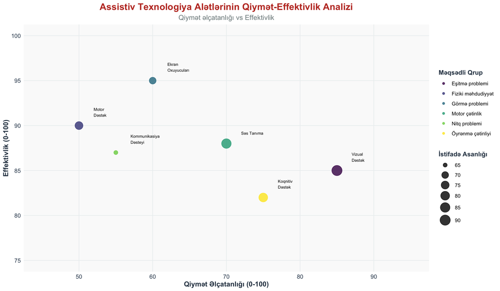

```r
# Assistiv texnologiya alətlərinin təhlili
assistive_tools <- tibble(
  Alət_Kateqoriyası = c("Ekran Oxuyucuları", "Səs Tanıma", "Vizual Dəstək",
                       "Motor Dəstək", "Koqnitiv Dəstək", "Kommunikasiya Dəsteyi"),
  Məqsədli_Qrup = c("Görmə problemi", "Motor çətinlik", "Eşitmə problemi",
                   "Fiziki məhdudiyyət", "Öyrənmə çətinliyi", "Nitq problemi"),
  İstifadə_Asanlığı = c(70, 85, 90, 75, 80, 65),
  Effektivlik = c(95, 88, 85, 90, 82, 87),
  Qiymət_Əlçatanlığı = c(60, 70, 85, 50, 75, 55),
  Texniki_Dəstək = c(80, 85, 90, 70, 88, 75)
)

# Alətlərin qiymət-effektivlik analizi
tech_plot <- assistive_tools %>%
  ggplot(aes(x = Qiymət_Əlçatanlığı, y = Effektivlik)) +
  geom_point(aes(color = Məqsədli_Qrup, size = İstifadə_Asanlığı), alpha = 0.8) +
  geom_text(aes(label = str_wrap(Alət_Kateqoriyası, 10)), hjust = 0, vjust = 0,
            nudge_x = 2, nudge_y = 1, size = 2.5) +
  scale_color_viridis_d(name = "Məqsədli Qrup") +
  scale_size_continuous(range = c(3, 8), name = "İstifadə Asanlığı") +
  scale_x_continuous(limits = c(45, 95)) +
  scale_y_continuous(limits = c(75, 100)) +
  labs(
    title = "Assistiv Texnologiya Alətlərinin Qiymət-Effektivlik Analizi",
    subtitle = "Qiymət əlçatanlığı vs Effektivlik",
    x = "Qiymət Əlçatanlığı (0-100)",
    y = "Effektivlik (0-100)"
  ) +
  theme_differential()

print(tech_plot)
```

```r
# Texnoloji tövsiyələr
tech_recommendations <- assistive_tools %>%
  mutate(
    Tövsiyə_Balı = (Effektivlik * 0.4) + (İstifadə_Asanlığı * 0.25) +
                   (Qiymət_Əlçatanlığı * 0.2) + (Texniki_Dəstək * 0.15)
  ) %>%
  arrange(desc(Tövsiyə_Balı)) %>%
  head(4)

kable(tech_recommendations %>% select(Alət_Kateqoriyası, Məqsədli_Qrup, Effektivlik, Tövsiyə_Balı),
      caption = "Tövsiyə Edilən Assistiv Texnologiya Alətləri",
      col.names = c("Alət Kateqoriyası", "Məqsədli Qrup", "Effektivlik (%)", "Tövsiyə Balı")) %>%
  kable_styling(bootstrap_options = c("striped", "hover", "condensed", "responsive")) %>%
  column_spec(1, bold = TRUE, color = "white", background = "#3498db") %>%
  column_spec(3:4, bold = TRUE) %>%
  row_spec(1, background = "#d4edda")
```

Tövsiyə Edilən Assistiv Texnologiya Alətləri

| Alət Kateqoriyası | Məqsədli Qrup | Effektivlik (%) | Tövsiyə Balı |
| --- | --- | --- | --- |
| Vizual Dəstək | Eşitmə problemi | 85 | 87.0 |
| Səs Tanıma | Motor çətinlik | 88 | 83.2 |
| Koqnitiv Dəstək | Öyrənmə çətinliyi | 82 | 81.0 |
| Ekran Oxuyucuları | Görmə problemi | 95 | 79.5 |

```r
cat("\n💻 ASSİSTİV TEXNOLOGİYA TÖVSİYƏLƏRİ:\n")
```

```
#>
#> 💻 ASSİSTİV TEXNOLOGİYA TÖVSİYƏLƏRİ:
```

```r
cat("======================================\n")
cat("🏆 Ən tövsiyə edilən:", tech_recommendations$Alət_Kateqoriyası[1], "\n")
```

```
#> 🏆 Ən tövsiyə edilən: Vizual Dəstək
```

```r
cat("💰 Ən əlçatan:", assistive_tools$Alət_Kateqoriyası[which.max(assistive_tools$Qiymət_Əlçatanlığı)], "\n")
```

```
#> 💰 Ən əlçatan: Vizual Dəstək
```

```r
cat("🎯 Ən effektiv:", assistive_tools$Alət_Kateqoriyası[which.max(assistive_tools$Effektivlik)], "\n")
```

```
#> 🎯 Ən effektiv: Ekran Oxuyucuları
```

```r
cat("⚡ Ən asan istifadə:", assistive_tools$Alət_Kateqoriyası[which.max(assistive_tools$İstifadə_Asanlığı)], "\n")
```

```
#> ⚡ Ən asan istifadə: Vizual Dəstək
```

## 7.1 Populyar Assistiv Texnologiyalar

**Ekran Oxuyucuları:** - NVDA, JAWS, VoiceOver - Mətn-səs çevirmə proqramları - Braille displeylər və printer-lər

**Səs Tanıma Proqramları:** - Dragon NaturallySpeaking - Windows Speech Recognition - Google Voice Typing

**Vizual Dəstək Alətləri:** - Magnification proqramları - Yüksək kontrastlı temalar - Rəng filtrləri və düzəlişləri

**Motor Dəstək Alətləri:** - Adaptiv klaviaturalar - Göz izləmə sistemləri - Switch-activated alətlər

# 8 Praktik Tətbiq Nümunələri

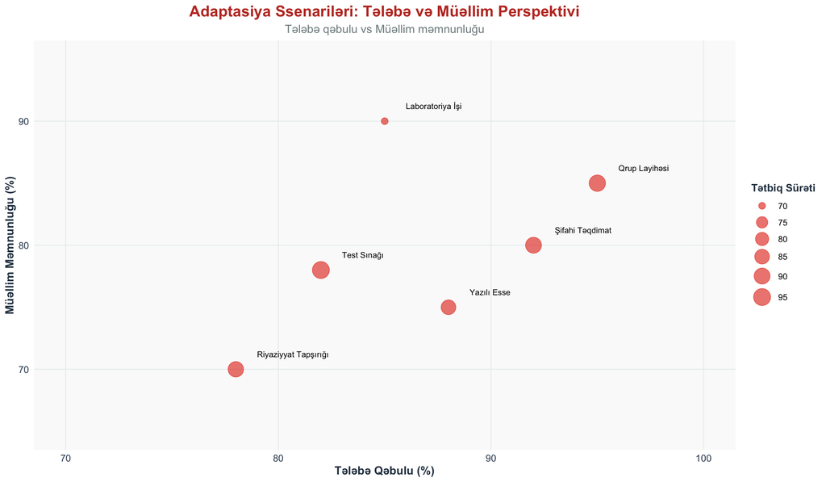

```r
# Müxtəlif ssenarilərdə adaptasiya nümunələri
adaptation_scenarios <- tibble(
  Ssenari = c("Yazılı Esse", "Şifahi Təqdimat", "Laboratoriya İşi",
              "Riyaziyyat Tapşırığı", "Qrup Layihəsi", "Test Sınağı"),
  Ənənəvi_Format = c("500 söz yazılı", "10 dəq təqdimat", "Laboratoriya hesabatı",
                    "20 məsələ həlli", "Qrup sunumu", "50 sual testi"),
  Adaptiv_Alternativ = c("Audio/Video/Poster", "Müxtəlif formatlar", "Praktik nümayiş",
                        "Vizual həllər", "Fərdi/qrup seçimi", "Çoxlu format"),
  Tələbə_Qəbulu = c(88, 92, 85, 78, 95, 82),
  Müəllim_Məmnunluğu = c(75, 80, 90, 70, 85, 78),
  Tətbiq_Sürəti = c(85, 90, 70, 88, 92, 95)
)

# Adaptasiya nümunələrinin müqayisəsi
scenario_plot <- adaptation_scenarios %>%
  ggplot(aes(x = Tələbə_Qəbulu, y = Müəllim_Məmnunluğu)) +
  geom_point(aes(size = Tətbiq_Sürəti), alpha = 0.7, color = "#e74c3c") +
  geom_text(aes(label = Ssenari), hjust = 0, vjust = 0,
            nudge_x = 1, nudge_y = 1, size = 3) +
  scale_size_continuous(range = c(3, 8), name = "Tətbiq Sürəti") +
  scale_x_continuous(limits = c(70, 100)) +
  scale_y_continuous(limits = c(65, 95)) +
  labs(
    title = "Adaptasiya Ssenariləri: Tələbə və Müəllim Perspektivi",
    subtitle = "Tələbə qəbulu vs Müəllim məmnunluğu",
    x = "Tələbə Qəbulu (%)",
    y = "Müəllim Məmnunluğu (%)"
  ) +
  theme_differential()

print(scenario_plot)
```

```r
# Ən uğurlu adaptasiya nümunələri
successful_adaptations <- adaptation_scenarios %>%
  mutate(
    Ümumi_Uğur = (Tələbə_Qəbulu * 0.4) + (Müəllim_Məmnunluğu * 0.35) + (Tətbiq_Sürəti * 0.25)
  ) %>%
  arrange(desc(Ümumi_Uğur)) %>%
  head(3)

kable(successful_adaptations %>% select(Ssenari, Ənənəvi_Format, Adaptiv_Alternativ, Ümumi_Uğur),
      caption = "Ən Uğurlu 3 Adaptasiya Nümunəsi",
      col.names = c("Ssenari", "Ənənəvi Format", "Adaptiv Alternativ", "Ümumi Uğur")) %>%
  kable_styling(bootstrap_options = c("striped", "hover", "condensed", "responsive")) %>%
  column_spec(1, bold = TRUE, color = "white", background = "#3498db") %>%
  column_spec(4, bold = TRUE, color = "#27ae60") %>%
  row_spec(1, background = "#d4edda")
```

Ən Uğurlu 3 Adaptasiya Nümunəsi

| Ssenari | Ənənəvi Format | Adaptiv Alternativ | Ümumi Uğur |
| --- | --- | --- | --- |
| Qrup Layihəsi | Qrup sunumu | Fərdi/qrup seçimi | 90.75 |
| Şifahi Təqdimat | 10 dəq təqdimat | Müxtəlif formatlar | 87.30 |
| Test Sınağı | 50 sual testi | Çoxlu format | 83.85 |

```r
cat("\n🎯 PRATİK ADAPTASIYA NƏTİCƏLƏRİ:\n")
```

```
#>
#> 🎯 PRATİK ADAPTASIYA NƏTİCƏLƏRİ:
```

```r
cat("===============================\n")
cat("🏆 Ən uğurlu adaptasiya:", successful_adaptations$Ssenari[1], "\n")
```

```
#> 🏆 Ən uğurlu adaptasiya: Qrup Layihəsi
```

```r
cat("❤️ Ən sevimli (tələbə):", adaptation_scenarios$Ssenari[which.max(adaptation_scenarios$Tələbə_Qəbulu)], "\n")
```

```
#> ❤️ Ən sevimli (tələbə): Qrup Layihəsi
```

```r
cat("👨‍🏫 Ən məqbul (müəllim):", adaptation_scenarios$Ssenari[which.max(adaptation_scenarios$Müəllim_Məmnunluğu)], "\n")
```

```
#> 👨‍🏫 Ən məqbul (müəllim): Laboratoriya İşi
```

```r
cat("⚡ Ən sürətli tətbiq:", adaptation_scenarios$Ssenari[which.max(adaptation_scenarios$Tətbiq_Sürəti)], "\n")
```

```
#> ⚡ Ən sürətli tətbiq: Test Sınağı
```

## 8.1 Praktik Adaptasiya Nümunələri

**Yazılı Esse Adaptasiyası:** - **Ənənəvi:** 500 söz yazılı esse - **Adaptiv alternativlər:** Audio podcast, infografik, video təqdimat, şeir, komiks

**Şifahi Təqdimat Adaptasiyası:** - **Ənənəvi:** 10 dəqiqəlik sinif qarşısında çıxış - **Adaptiv alternativlər:** Video qeydiyyatı, kiçik qrup təqdimatı, peer-to-peer danışıq

**Riyaziyyat Tapşırığı Adaptasiyası:** - **Ənənəvi:** 20 məsələ həlli kağızda - **Adaptiv alternativlər:** Vizual diaqramlar, manipulativ istifadəsi, rəqəmsal kalkulyator

# 9 Dərsin Praktik Tapşırığı

## 9.1 Final Layihəsi: Differensial Qiymətləndirmə Sistemi

**Tapşırıq 1: Tələbə Ehtiyacları Xəritəsi** 1. Sinifiniz üçün tələbə ehtiyacları sorğusu aparın 2. Fərdi öyrənmə profillərini müəyyənləşdirin 3. Adaptasiya prioritetlərini təyin edin 4. R-də ehtiyaclar təhlilini həyata keçirin

**Tapşırıq 2: İnklüziv Rubrik Hazırlama** 1. Fənniniz üçün inklüziv rubrik yaradın 2. Universal dizayn prinsiplərini tətbiq edin 3. Müxtəlif alternativ qiymətləndirmə formatları təklif edin 4. Pilot test aparıb effektivliyi ölçün

**Tapşırıq 3: Adaptasiya Strategiya Planı** 1. Konkret adaptasiya strategiyaları kataloqunu hazırlayın 2. Hər xüsusi ehtiyac üçün spesifik təkliflər 3. Texnoloji dəstək və resurs xəritəsi 4. Tətbiq vaxt cədvəli və mərhələlər

**Tapşırıq 4: Assistiv Texnologiya İnteqrasiyası** 1. Mövcud texnoloji imkanları araşdırın 2. Büdcə və resurs planlaması 3. Müəllim və tələbə təlimi strategiyası 4. Uğur metrikləri və qiymətləndirmə sistemi

**Təslim Formatı:** R Markdown hesabatı + İnklüziv Materiallar + Tətbiq Planı

**Təslim Müddəti:** 2 həftə

**Qiymətləndirmə:** İnklüzivlik dərəcəsi, praktiklik və innovasiya

# 10 Dərsin Xülasəsi və Əsas Nəticələr

Bu dərsdə əldə etdiyiniz əsas bacarıqlar:

✅ **Differensial qiymətləndirmə fəlsəfəsi:** Fərdi ehtiyaclara cavab verən qiymətləndirmə

✅ **Fərqlilikləri tanıma:** Müxtəlif öyrənmə üslubları və xüsusi ehtiyacları anlama

✅ **İnklüziv rubrik dizaynı:** Bütün tələbələr üçün ədalətli qiymətləndirmə rubrikləri

✅ **Universal dizayn prinsipləri:** UDL çərçivəsində əlçatan qiymətləndirmə

✅ **Texnoloji dəstək:** Assistiv texnologiyalar və rəqəmsal adaptasiya

✅ **Praktik tətbiq:** Real sinif mühitində inklüziv strategiyaların həyata keçirilməsi

## 10.1 Vacib Xatırlatmalar

> **🌍 İnklüzivlik Prinsipi:** Hər tələbə öz potensialını tam şəkildə nümayiş etdirmək hüququna malikdir. Differensial qiymətləndirmə bu hüququn təmin edilməsi üçün əsas vasitədir.

> **⚖️ Ədalətlilik və Bərabərlik:** Ədalətli qiymətləndirmə hər kəsə eyni şeyi vermək deyil, hər kəsin ehtiyacı olana vermək deməkdir.

## 10.2 Gələcək İnkişaf İstiqamətləri

**Növbəti Trendlər:** - AI əsaslı fərdi adaptasiya sistemləri - Virtual reallıq və immersiv öyrənmə mühitləri - Biomətriya və neyrotexnologiya dəsteyi - Blokçeyn əsaslı sertifikasiya sistemləri

## 10.3 **DƏRS 6 TAMAMLANDI! 🎉**

**Differensial qiymətləndirmə və inklüziv yanaşımları uğurla mənimsədiniz!**

**İndi bütün tələbələriniz üçün ədalətli və əlçatan qiymətləndirmə mühiti yarada bilərsiniz! 🌟**

### 10.3.1 Növbəti Addımlar

1. **Tələbə Ehtiyacları Araşdırması:** Sinifinizdə mövcud fərqlilikləri müəyyənləşdirin
2. **Adaptasiya Strategiyalarının Tətbiqi:** Konkret adaptasiya planları həyata keçirin
3. **Texnoloji Dəstək Axtarışı:** Mövcud assistiv texnologiya imkanlarını araşdırın
4. **Həmkar Əməkdaşlığı:** Digər müəllimlər və mütəxəssislərlə təcrübə mübadiləsi

**📚 Növbəti dərs mövzuları:** - Portfolio əsaslı qiymətləndirmə - Performans əsaslı qiymətləndirmə - Standartlaşdırılmış test hazırlama - Qiymətləndirmə məlumatlarının analizi

**Hər tələbənin uğur şansı olsun! 🌈**